# Lecture 05: Time Series Analysis Basics

Author

Timothy Chia

Published

June 2, 2026

```r
library(ggplot2)
library(dplyr)
library(tidyr)
library(readr)
library(purrr)
library(tibble)
library(lubridate)
library(stringr)
library(tidyquant)
library(readxl)

set_theme <- function() {
  theme_bw() +
    theme(
      panel.background = element_rect(fill = "#fffdf0", colour = NA),
      panel.grid.major = element_line(colour = "grey70", linetype = "dashed"),
      panel.grid.minor = element_line(colour = "grey90")
    )
}
```

# 1 What is Time Series?

- A time series is a sequence of observations recorded at regular time intervals.
- Time series data is used in various fields such as economics, finance, statistics, and signal processing.
- Time series analysis is related to two major tasks:
  - **Modelling** (descriptive): Identifying patterns (e.g., trend, seasonality, cyclicality, etc.).
  - **Forecasting** (predictive): Predicting future values based on historical data.
- Example: Daily and Monthly Adjusted Close Prices of NVIDIA Corp. (NASDAQ: NVDA).

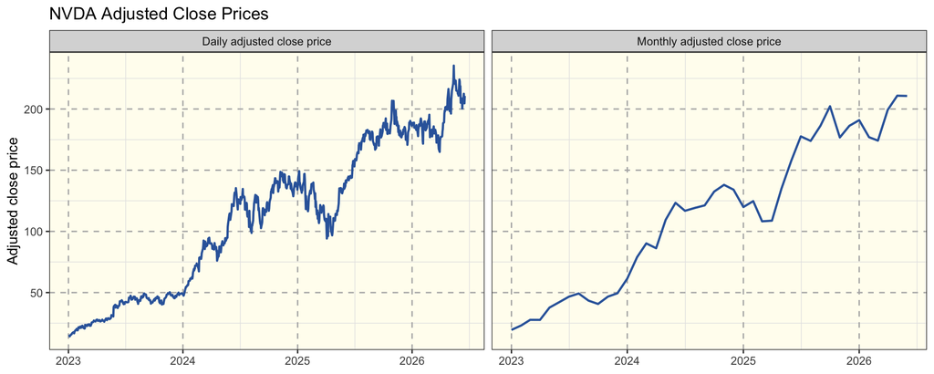

Daily and monthly adjusted close prices of NVIDIA Corp. (NASDAQ: NVDA).

# 2 More Time Series Examples

- Time Series 1: [Monthly coal consumption for electricity generation in the United States (2022-2024)](https://www.eia.gov/electricity/monthly/)
- Time Series 2: [Monthly average surface temperature by year, United States (2022-2024)](https://ourworldindata.org/grapher/monthly-average-surface-temperatures-by-year?facet=none&country=~USA)

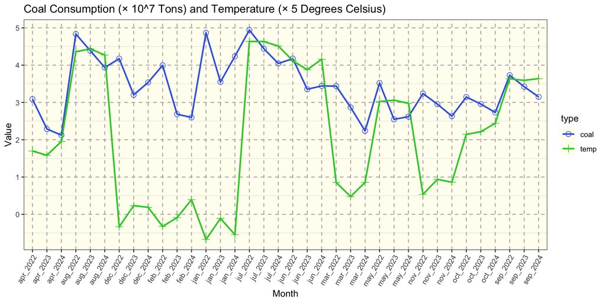

Monthly coal consumption and average surface temperature in the United States, 2022-2024.

# 3 Time Series Components

- Trend: A long-term increase or decrease in the data.
  - Upward, downward, or flat.
  - Can be linear or nonlinear.
- Seasonality: A pattern that repeats at regular intervals.
  - Regular intervals (daily, monthly, yearly).
  - Driven by known factors (climate, behaviour).
- Cyclicality: A pattern that repeats at irregular intervals.
  - Irregular intervals (months, year)
  - Caused by macroeconomic or systemic changes.
- Examples:
  - S&P 500 and NASDAQ show an upward trend over decades.
  - Retail sales show seasonality with peaks during holidays.
  - Economic recessions and booms occur every several years but are not fixed like seasonality.
  - There is a hypothesis that the crypto market cycles are driven by Bitcoin halving events.

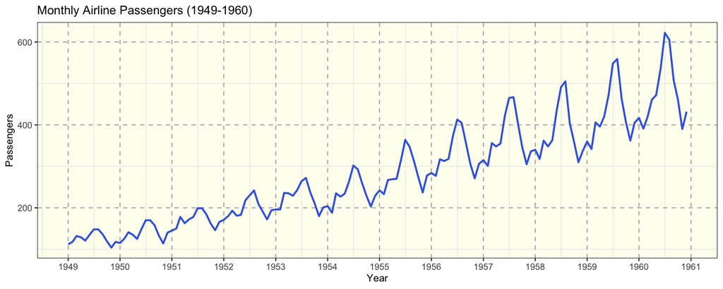

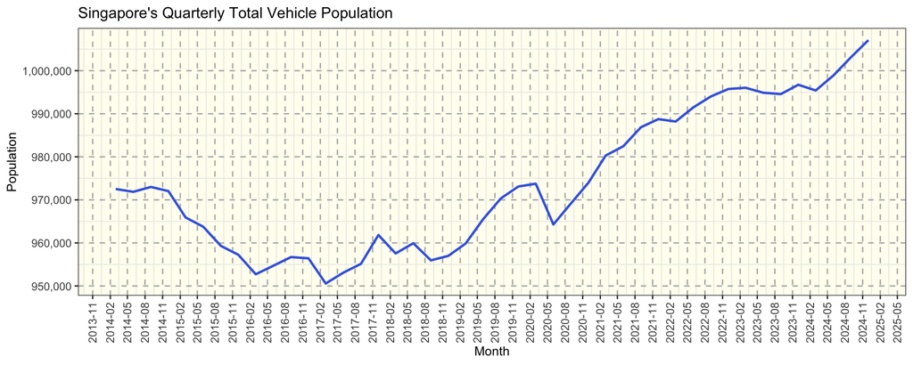

# 4 The Big Picture

A full-scale journey into time series analysis includes the following topics and more:

- Background knowledge (Statistics, Probability, Linear Algebra, Calculus, etc.)
- Curve Fitting and Smoothing
- Stationarity and Adjustment (Decomposition, ADF and KPSS Test, Adjustment, etc.)
- Classical Time Series Models (AR, MA, ARMA, ARIMA, Seasonal ARIMA, ARIMAX, etc.)
- Advanced and Multivariate Time Series Models
- Machine Learning for Time Series Analysis (Boosting, Random Forest, etc.)
- Deep Learning for Time Series Analysis (RNN, LSTM, Transformer, etc.)

In this course, we will only cover the following:

- Stationarity and Adjustment
  - Definition of Stationarity
  - Stationarity Test and Adjustment Techniques
- Classical Time Series models
  - Autoregressive (AR)
  - Moving Average (MA)
  - Autoregressive Moving Average (ARMA)
  - Autoregressive Integrated Moving Average (ARIMA)

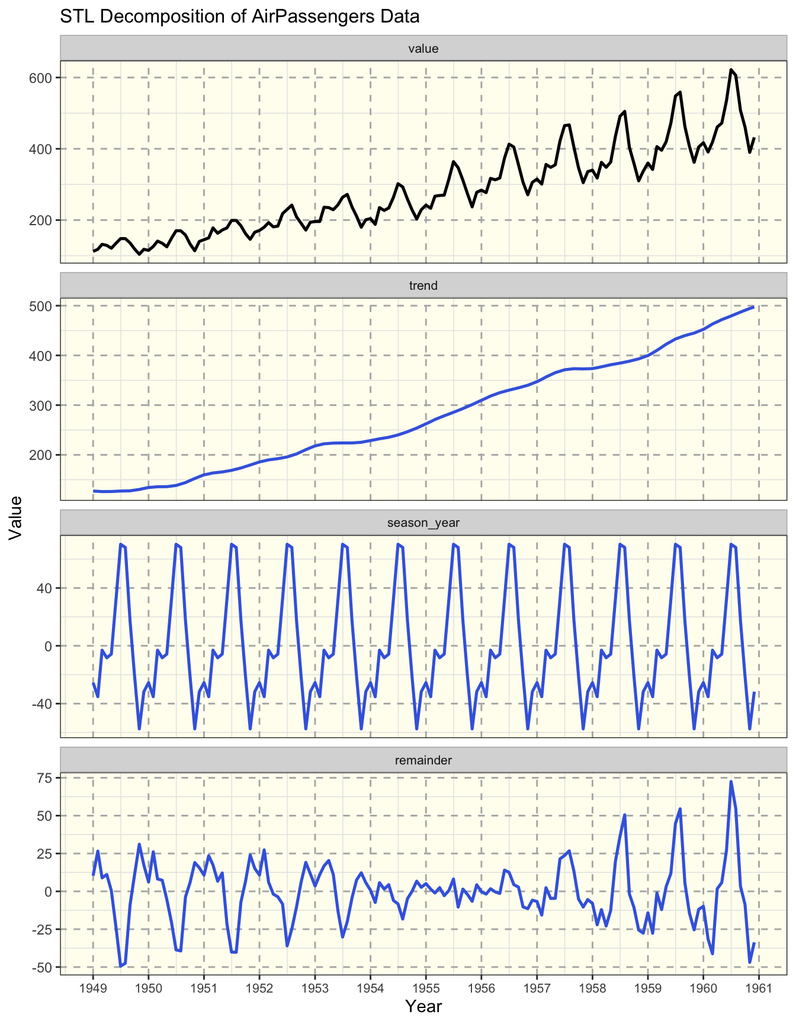

# 5 Stationarity

- A time series can be modelled by a stochastic process (or random process) for theoretical analysis.
- **Stationarity:** A time series is stationary if its statistical properties (mean, variance, etc.) are constant over time.
  - A seasonal time series is not stationary because the mean and variance change at seasonal intervals.
  - A trended time series is not stationary because the mean changes over time.
  - One classic example of a theoretically stationary time series is the observation of a collection of independent and identically distributed (i.i.d.) random variables over time, which is one of the most important concepts in many fields.
- Some time series can be transformed into stationary time series by removing the non-stationary components. This leads to the concepts of **trend stationary** (stationary if the trend is removed) and **seasonal stationary** (stationary if the seasonality is removed).
- **Importance of Stationarity:**
  - Many time series models assume stationarity.
  - Stationarity simplifies the analysis and interpretation of time series data.
  - Stationarity is a key assumption in many statistical procedures used in time series analysis.

**Tip**

A stochastic process can be strict-sense stationary (SSS), wide-sense stationary (WSS), or $n$th-order stationary. For more information, visit [here](https://en.wikipedia.org/wiki/Stationary_process).

## 5.1 Stationarity Test

### 5.1.1 Example: i.i.d. Gaussian Process

- i.i.d. Gaussian process (aka Gaussian white noise) is a classic stationary time series used in many fields.

The figure below shows a time series of 1000 i.i.d. Gaussian random variables with mean 0 and standard deviation 1.

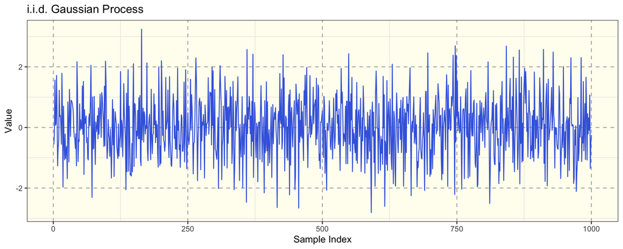

```r
# generate a time series of 1000 i.i.d. Gaussian random variables
set.seed(123)
iid_gaussian <- tibble(
  index = 1:1000,
  value = rnorm(1000, mean = 0, sd = 1)
)

# plot the time series with ggplot
iid_gaussian |>
  ggplot(aes(x = index, y = value)) +
  geom_line(colour = "royalblue", linewidth = 0.5) +
  labs(
    title = "i.i.d. Gaussian Process",
    x = "Sample Index",
    y = "Value"
  ) +
  set_theme()
```

The figure below shows the histogram of the generated values.

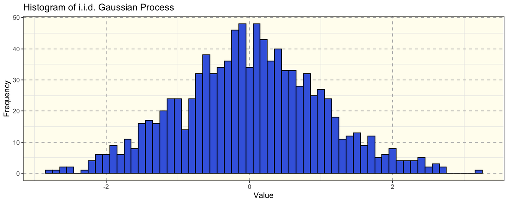

```r
# calculate the histogram of the generated time series
iid_gaussian |>
  ggplot(aes(x = value)) +
  geom_histogram(binwidth = 0.1, fill = "royalblue", color = "black") +
  labs(
    title = "Histogram of i.i.d. Gaussian Process",
    x = "Value",
    y = "Frequency"
  ) +
  set_theme()
```

The figure below shows the normalised histogram of the generated values. The red curve is the theoretical standard normal density.

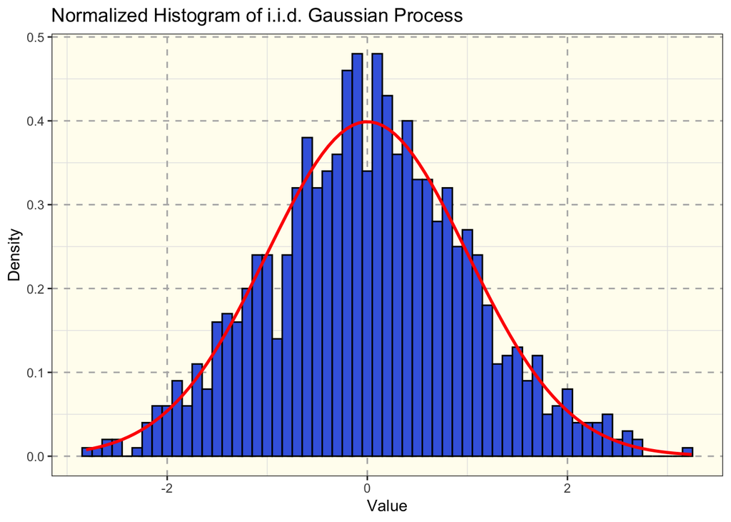

```r
# normalise the historgram counts to density scale
iid_gaussian |>
  ggplot(aes(x = value)) +
  geom_histogram(aes(y = after_stat(density)), binwidth = 0.1, fill = "royalblue", color = "black") +
  labs(
    title = "Normalized Histogram of i.i.d. Gaussian Process",
    x = "Value",
    y = "Density"
  ) +
  stat_function(fun = dnorm, args = list(mean = 0, sd = 1), colour = "red", linewidth = 1) +
  set_theme()
```

The figure below shows the autocorrelation function (ACF) of the series.

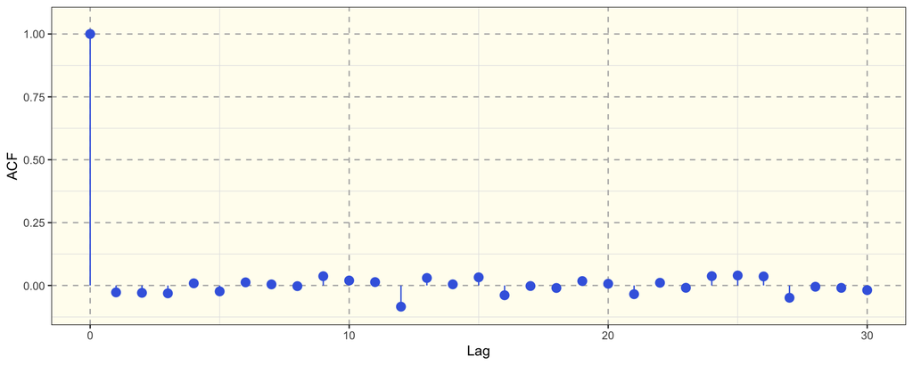

```r
# Plot the autocorrelation function of the series (ACF)
acf_iid_gaussian <- acf(iid_gaussian$value, lag.max = 30, plot = FALSE)
acf_iid_gaussian <- tibble(lag = acf_iid_gaussian$lag, acf = acf_iid_gaussian$acf)
acf_iid_gaussian |>
  ggplot(aes(x = lag, y = acf)) +
  geom_segment(aes(xend = lag, yend = 0), color = "royalblue") +
  geom_point(color = "royalblue", size = 3) +
  ylim(-0.1, 1.05) +
  labs(x = "Lag", y = "ACF") + set_theme()
```

The figure below shows the partial autocorrelation function (PACF) of the series.

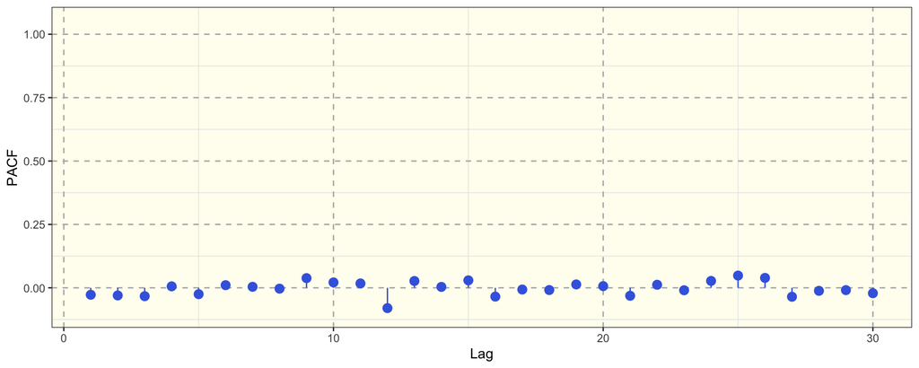

```r
# Plot the partial autocorrelation function of the series (PACF)
pacf_iid_gaussian <- pacf(iid_gaussian$value, lag.max = 30, plot = FALSE)
pacf_iid_gaussian <- tibble(lag = pacf_iid_gaussian$lag, pacf = pacf_iid_gaussian$acf)
pacf_iid_gaussian |>
  ggplot(aes(x = lag, y = pacf)) +
  geom_segment(aes(xend = lag, yend = 0), color = "royalblue") +
  geom_point(color = "royalblue", size = 3) +
  ylim(-0.1, 1.05) +
  labs(x = "Lag", y = "PACF") + set_theme()
```

## 5.2 Stationarity Adjustment

- Since stationarity is an underlying assumption in many statistical procedures used in time series analysis, non-stationary data are often transformed to become statnary before further analysis.
- De-trending and de-seasonalizing are two common operations to adjust non-stationary time series data.
- De-trending techniques:
  - Differencing: Subtracting the series from its lagged version.
  - Fitted Trned Subtraction: Subtracting the fitted trend.
  - Moving Average Subtraction: Substracting the moving averages.
- Example: NVDIA Monthly Prices

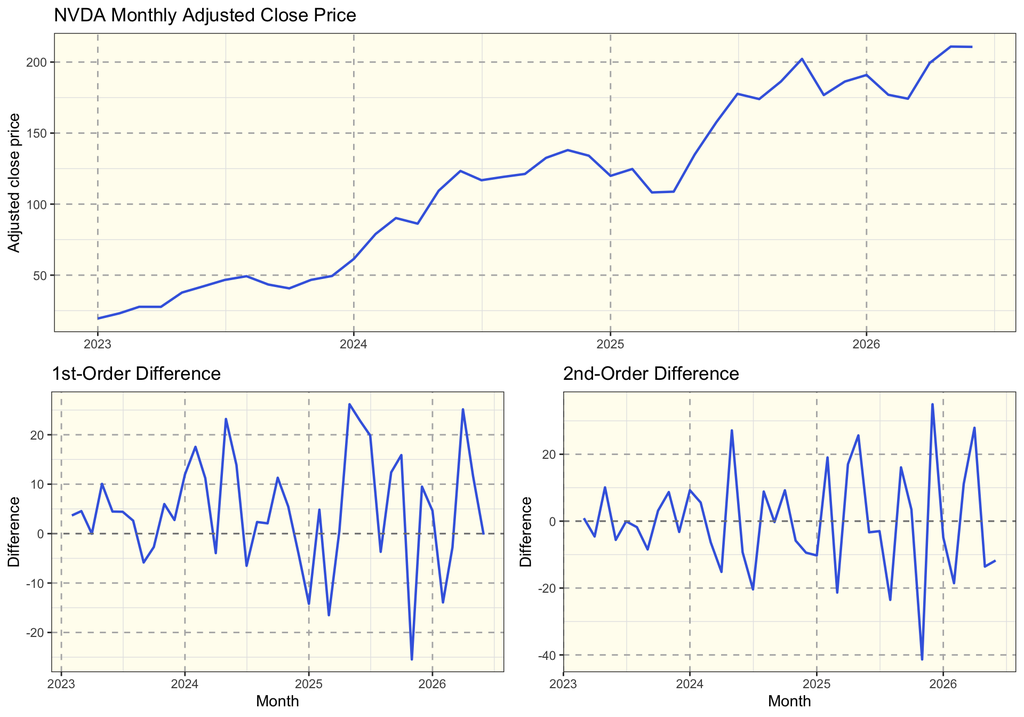

### 5.2.1 Example: Random Walk

A random walk is defined as:
$$x_t = x_{t-1} + w_t,$$
where $w_t \sim \text{i.i.d. } \mathcal{N}(0, \sigma_w^2)$.

- **Mean:** $\mathbb{E}[x_t] = 0$
- **Variance:** $\text{Var}(x_t) = t \cdot \sigma_w^2$

The variance grows linearly with time, which indicates the random walk is **non-stationary** — its statistical properties change over time.

To detrend the random walk, we can take the **first-order difference**, i.e., subtracting the series from its lagged version. The differenced series recovers the original i.i.d. noise and becomes stationary.

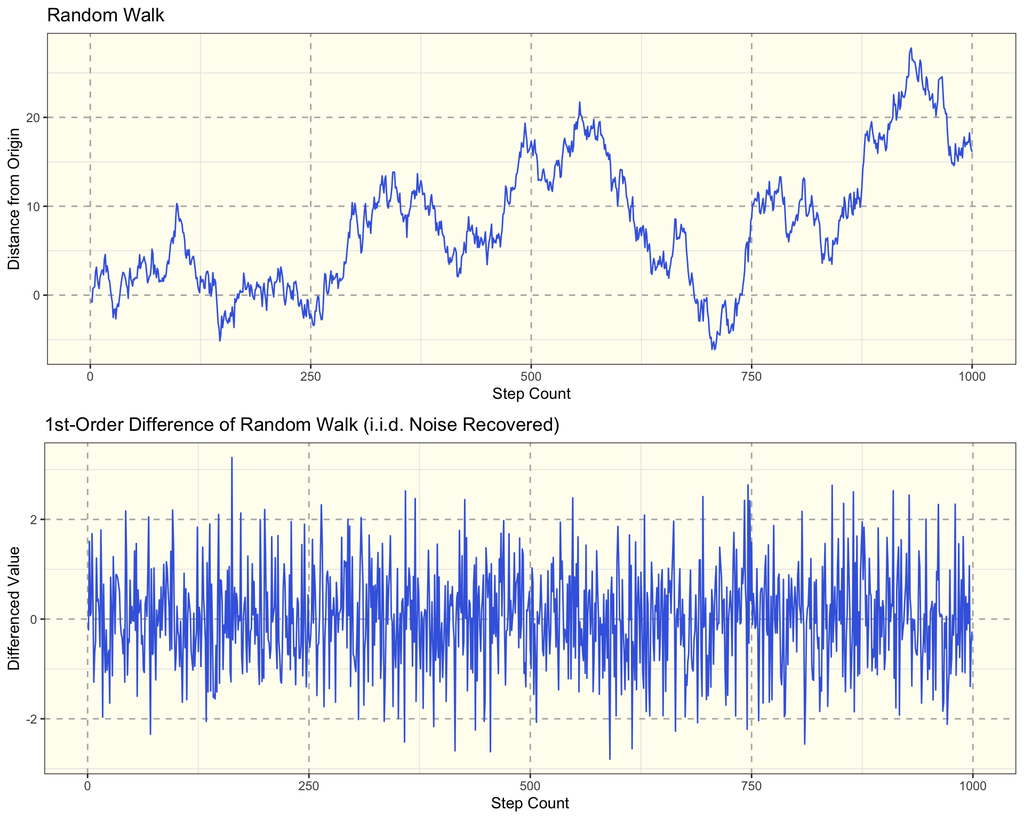

```r
# Generate a random walk time series
set.seed(123)
random_walk <- tibble(
  step = 1:1000,
  value = cumsum(rnorm(1000, mean = 0, sd = 1))
)

# Plot the random walk
rw_plot <- random_walk |>
  ggplot(aes(x = step, y = value)) +
  geom_line(colour = "royalblue", linewidth = 0.5) +
  labs(
    title = "Random Walk",
    x = "Step Count",
    y = "Distance from Origin"
  ) +
  set_theme()

# Plot the 1st-order difference
rw_diff_plot <- random_walk |>
  mutate(diff = value - lag(value)) |>
  drop_na(diff) |>
  ggplot(aes(x = seq_along(diff), y = diff)) +
  geom_line(colour = "royalblue", linewidth = 0.5) +
  labs(
    title = "1st-Order Difference of Random Walk (i.i.d. Noise Recovered)",
    x = "Step Count",
    y = "Differenced Value"
  ) +
  set_theme()

grid::grid.newpage()
plot_layout <- grid::grid.layout(nrow = 2, ncol = 1)
grid::pushViewport(grid::viewport(layout = plot_layout))
print(rw_plot, vp = grid::viewport(layout.pos.row = 1, layout.pos.col = 1))
print(rw_diff_plot, vp = grid::viewport(layout.pos.row = 2, layout.pos.col = 1))
```

**Tip**

For the derivation of the mean and variance of a sum of i.i.d. Gaussian variables, visit [here](https://en.wikipedia.org/wiki/Sum_of_normally_distributed_random_variables).

# 6 Autoregressive (AR) Model

A revised random walk condition introduces a coefficient $\phi$:
$$x_t = \phi \cdot x_{t-1} + w_t,$$
where $w_t \sim \text{i.i.d. } \mathcal{N}(0, \sigma_w^2)$.

- If $|\phi| < 1$, the process is **stationary** (mean-reverting).
- If $\phi = 1$, we obtain a **random walk** (non-stationary).
- If $|\phi| > 1$, the process is **explosive** (non-stationary).

More generally, a $p$th-order autoregressive model, i.e., $\text{AR}(p)$, is defined as:
$$x_t = a_1 x_{t-1} + a_2 x_{t-2} + \dots + a_p x_{t-p} + w_t,$$
where $a_1, a_2, \dots, a_p$ are the model parameters, $a_p \neq 0$, and $w_t$ is the white noise term.

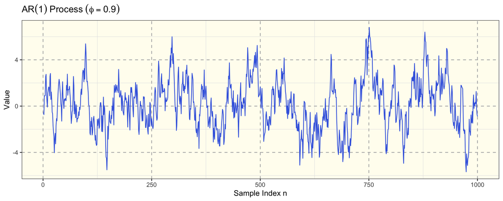

```r
# Generate an AR(1) process with phi = 0.9
set.seed(123)
n <- 1000
x <- numeric(n)
w <- rnorm(n, mean = 0, sd = 1)
x[1] <- w[1]
for (i in 2:n) x[i] <- 0.9 * x[i-1] + w[i]
ar1 <- tibble(index = 1:n, value = x)

ar1 |>
  ggplot(aes(x = index, y = value)) +
  geom_line(colour = "royalblue", linewidth = 0.5) +
  labs(
    title = expression(AR(1) ~ Process ~ (phi == 0.9)),
    x = "Sample Index n",
    y = "Value"
  ) +
  set_theme()
```

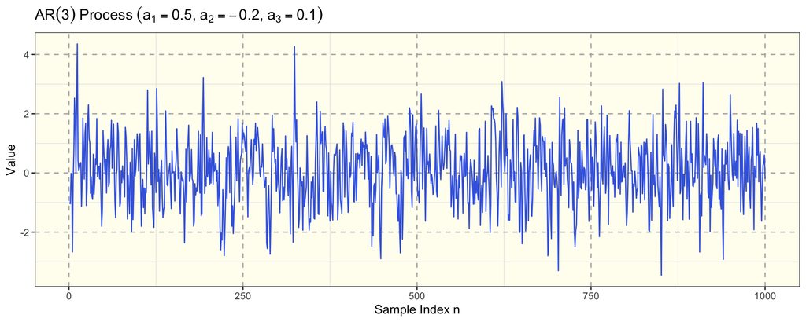

```r
# Generate an AR(3) process with a1 = 0.5, a2 = -0.2, a3 = 0.1
x <- numeric(n)
w <- rnorm(n, mean = 0, sd = 1)
x[1:3] <- w[1:3]
for (i in 4:n) x[i] <- 0.5 * x[i-1] - 0.2 * x[i-2] + 0.1 * x[i-3] + w[i]
ar3 <- tibble(index = 1:n, value = x)

ar3 |>
  ggplot(aes(x = index, y = value)) +
  geom_line(colour = "royalblue", linewidth = 0.5) +
  labs(
    title = expression(AR(3) ~ Process ~ (a[1] == 0.5 * "," ~ a[2] == -0.2 * "," ~ a[3] == 0.1)),
    x = "Sample Index n",
    y = "Value"
  ) +
  set_theme()
```

**Note**

An AR model describes how today’s value depends on previous observations. For example, today’s temperature is dependent on yesterday’s and possibly a few previous days’, where the order $p$ determines how many previous days are considered.

# 7 Moving Average (MA) Model

A $q$th-order moving average model, i.e., $\text{MA}(q)$, is defined as:
$$x_t = w_t + b_1 w_{t-1} + b_2 w_{t-2} + \dots + b_q w_{t-q},$$
where $b_1, b_2, \dots, b_q$ are the model parameters (no need to be bounded), and $w_t$ is the white noise term.

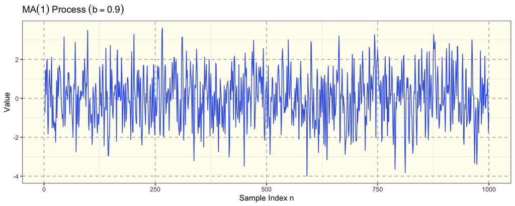

```r
# Generate an MA(1) process with b = 0.9
set.seed(123)
n <- 1000
w <- rnorm(n, mean = 0, sd = 1)
x <- numeric(n)
x[1] <- w[1]
for (i in 2:n) x[i] <- w[i] + 0.9 * w[i-1]
ma1 <- tibble(index = 1:n, value = x)

ma1 |>
  ggplot(aes(x = index, y = value)) +
  geom_line(colour = "royalblue", linewidth = 0.5) +
  labs(
    title = expression(MA(1) ~ Process ~ (b == 0.9)),
    x = "Sample Index n",
    y = "Value"
  ) +
  set_theme()
```

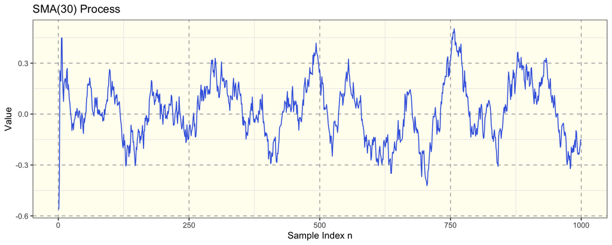

```r
# Generate an SMA(30) process
x <- numeric(n)
for (i in 1:n) x[i] <- mean(w[max(i - 30, 1):i])
sma30 <- tibble(index = 1:n, value = x)

sma30 |>
  ggplot(aes(x = index, y = value)) +
  geom_line(colour = "royalblue", linewidth = 0.5) +
  labs(
    title = "SMA(30) Process",
    x = "Sample Index n",
    y = "Value"
  ) +
  set_theme()
```

**Note**

The simple moving average (SMA) curve, i.e., MA with uniform weights, is a common smoothing technique for stock price analysis. It has variations such as the exponential moving average (EMA).

# 8 Autoregressive Moving Average (ARMA) Model

Combining the AR and MA models, we obtain the ARMA model. Formally, an $\text{ARMA}(p, q)$ model is defined as:
$$x_t = a_1 x_{t-1} + \dots + a_p x_{t-p} + w_t + b_1 w_{t-1} + \dots + b_q w_{t-q},$$
where $a_1, \dots, a_p, b_1, \dots, b_q$ are the model parameters, $a_p \neq 0$, $b_q \neq 0$, and $w_t$ is the white noise term.

The ARMA model generalises both the AR and MA models: - $\text{ARMA}(p, 0) = \text{AR}(p)$ - $\text{ARMA}(0, q) = \text{MA}(q)$

# 9 Autoregressive Integrated Moving Average (ARIMA) Model

The ARIMA model extends ARMA by adding an **integration** (differencing) component. It is denoted as $\text{ARIMA}(p, d, q)$:

- **AR** ($p$): The variable of interest is regressed on its prior values.
- **I** ($d$): The data values are replaced with the difference between each value and the previous one (applied $d$ times to achieve stationarity).
- **MA** ($q$): The AR error is a linear combination of errors that occurred at various times in the past.

Taking the $d$th difference of a non-stationary series yields a stationary $\text{ARMA}(p, q)$ model.

**Note**

**Applications of ARIMA models:** - The random walk model is $\text{ARIMA}(0, 1, 0)$, while white noise is $\text{ARIMA}(0, 0, 0)$. - ARIMA models (e.g., $\text{ARIMA}(1, 1, 1)$) have been used to forecast stock prices, indices, and exchange rates, capturing both trends and short-term fluctuations. - ARIMA was used to forecast COVID-19 cases, hospitalisations, and deaths. - Power companies like National Grid, Tesla, and Siemens use ARIMA to predict electricity demand. - ARIMA models traffic congestion in cities to help navigation apps like Google Maps and Waze.

# 10 ARMA Modelling and Forecasting Workflow

Let us begin with a stationary time series (detrended or stationary in nature). We want to build an $\text{ARMA}(p, q)$ model: to find $p$ and $q$ that best fit the data.

## 10.1 ACF and PACF

Two diagnostic tools help determine the correlation structure and stationarity of a series:

- **Autocorrelation Function (ACF):** Measures the correlation between the series and its lagged values.
- **Partial Autocorrelation Function (PACF):** Measures the correlation between the series and its lagged values, controlling for intermediate lags.

**Theoretical patterns** for ideal, infinite-length processes:

| Model | ACF | PACF |
| --- | --- | --- |
| $\text{AR}(p)$ | Tails off (geometric) | Cuts off after lag $p$ |
| $\text{MA}(q)$ | Cuts off after lag $q$ | Tails off (geometric) |
| $\text{ARMA}(p, q)$ | Tails off (geometric) | Tails off (geometric) |

**Warning**

These patterns are rarely clean in practice, and even ideal synthetic signals can look ambiguous. ACF and PACF are more reliable for detecting **non-stationarity** (slow ACF decay suggests differencing is needed) and **seasonality** (spikes at multiples of the period). For order selection, rely on AIC, BIC, and `auto.arima()`.

## 10.2 Model Order Selection

The standard procedure for ARMA modelling is:

1. Guess a few $(p, q)$ combinations.
2. Fit the ARMA models.
3. Compare model performance using **AIC** (Akaike Information Criterion) or **BIC** (Bayesian Information Criterion).
4. Select the model with the smallest AIC or BIC.

```r
library(forecast)

# Detrend NVDA daily prices to obtain a stationary series
nvda_stationary <- nvda_daily |>
  mutate(diff = adjusted - lag(adjusted)) |>
  drop_na(diff)

# Fit ARMA models with different orders
fit_arma1 <- arima(nvda_stationary$diff, order = c(1, 0, 1))
fit_arma2 <- arima(nvda_stationary$diff, order = c(2, 0, 1))
fit_arma3 <- arima(nvda_stationary$diff, order = c(1, 0, 2))
fit_arma4 <- arima(nvda_stationary$diff, order = c(2, 0, 2))

# Compare AIC and BIC
AIC(fit_arma1, fit_arma2, fit_arma3, fit_arma4)
```

```
          df      AIC
fit_arma1  4 4622.027
fit_arma2  5 4623.052
fit_arma3  5 4622.522
fit_arma4  6 4617.021
```

```r
BIC(fit_arma1, fit_arma2, fit_arma3, fit_arma4)
```

```
          df      BIC
fit_arma1  4 4641.087
fit_arma2  5 4646.877
fit_arma3  5 4646.347
fit_arma4  6 4645.611
```

The `forecast::auto.arima()` function can automatically select the best ARIMA model based on AIC or BIC.

```r
# Automatic model selection using AIC
auto_fit_aic <- auto.arima(
  nvda_stationary$diff,
  ic = "aic",
  seasonal = FALSE,
  stationary = TRUE
)

# Inspect the selected model
auto_fit_aic
```

```
Series: nvda_stationary$diff
ARIMA(0,0,4) with non-zero mean

Coefficients:
          ma1     ma2      ma3      ma4    mean
      -0.0813  0.0636  -0.0927  -0.0911  0.2260
s.e.   0.0340  0.0340   0.0352   0.0331  0.0932

sigma^2 = 11.86:  log likelihood = -2299.94
AIC=4611.88   AICc=4611.98   BIC=4640.47
```

## 10.3 Forecasting

With the fitted ARMA model, we can forecast future values. Prediction intervals provide a measure of uncertainty around point forecasts.

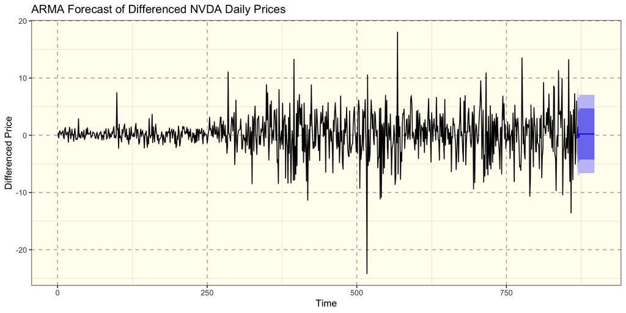

```r
# Forecast 30 steps ahead
forecast(auto_fit_aic, h = 30) |>
  autoplot() +
  labs(
    x = "Time",
    y = "Differenced Price",
    title = "ARMA Forecast of Differenced NVDA Daily Prices"
  ) +
  set_theme()
```

**Note**

ARMA forecasts tend to converge to the mean of the series over longer horizons. This is a natural property of stationary processes: the best long-term forecast is the unconditional mean.

# 11 Forecasting Non-Stationary Time Series

Here we demonstrate forecasting with ARIMA models on several real-world non-stationary time series. The `auto.arima()` function automatically handles differencing and seasonality.

## 11.1 NVIDIA Monthly Prices

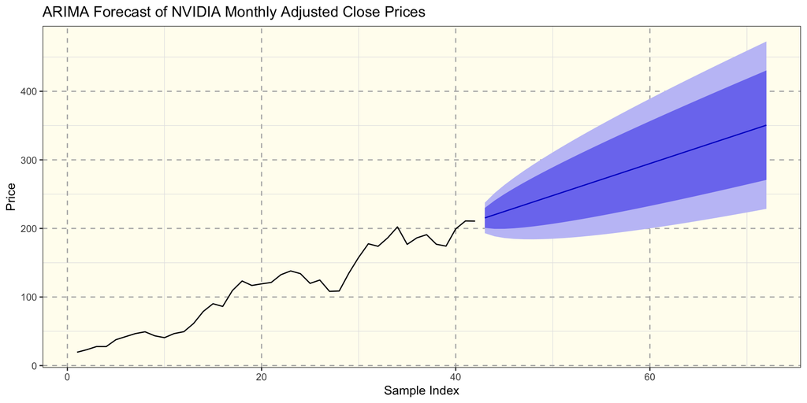

```r
model_nvidia <- auto.arima(nvda_monthly$adjusted)

model_nvidia |>
  forecast(h = 30) |>
  autoplot() +
  labs(
    x = "Sample Index",
    y = "Price",
    title = "ARIMA Forecast of NVIDIA Monthly Adjusted Close Prices"
  ) +
  set_theme()
```

## 11.2 BTC Monthly Prices

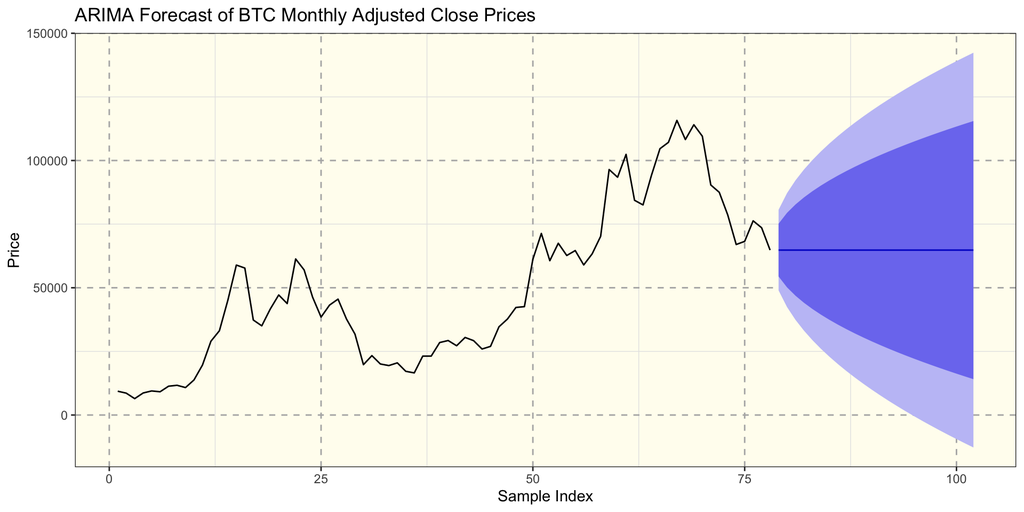

```r
btc_monthly <- tq_get(
  "BTC-USD",
  from = "2020-01-01",
  to = Sys.Date(),
  get = "stock.prices"
) |>
  select(date, adjusted) |>
  mutate(date = floor_date(date, "month")) |>
  group_by(date) |>
  summarise(adjusted = last(adjusted), .groups = "drop")

model_btc <- auto.arima(btc_monthly$adjusted)

model_btc |>
  forecast(h = 24) |>
  autoplot() +
  labs(
    x = "Sample Index",
    y = "Price",
    title = "ARIMA Forecast of BTC Monthly Adjusted Close Prices"
  ) +
  set_theme()
```

## 11.3 Airline Passengers

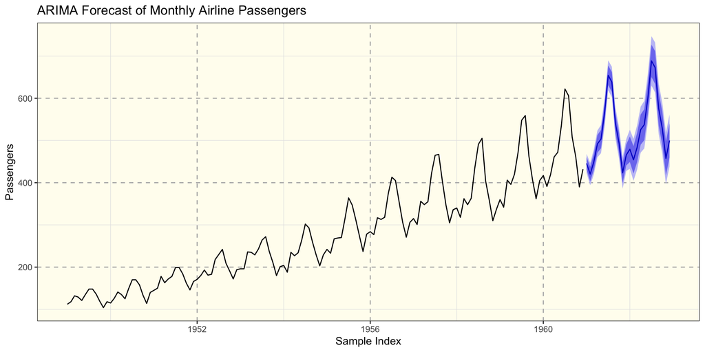

```r
model_air <- auto.arima(AirPassengers)

model_air |>
  forecast(h = 24) |>
  autoplot() +
  labs(
    x = "Sample Index",
    y = "Passengers",
    title = "ARIMA Forecast of Monthly Airline Passengers"
  ) +
  set_theme()
```

# 12 Summary

We have covered the following topics:

1. Time series definition, components, and types.
2. Time series decomposition and stationarity.
3. Stationarity tests and adjustment techniques.
4. AR, MA, ARMA, and ARIMA models.
5. ARIMA modelling workflow with ACF, PACF, AIC, and BIC.
6. ARIMA-based forecasting of several real-world time series.

This is an introductory session, in which the mathematical details are not fully covered. It is intended to open the door for more advanced time series analysis and forecasting techniques.

## 12.1 References

- [*Forecasting: Principles and Practice*](https://otexts.com/fpp3/) by R. J. Hyndman and G. Athanasopoulos.
- [*Time Series Analysis Lectures*](https://bookdown.org/abkashlak/TSaLectures/) by A. B. Kashlak.
- [*Time Series Analysis and Its Applications with R Examples*](https://www.stat.pitt.edu/stoffer/tsa4/) by R. H. Shumway and D. S. Stoffer.